# *Brachypodium distachyon* infected with various isolates of *Zymoseptoria tritici*

Harriet R. Benbow

02/07/2020

# 1 Introduction

The purpose of this analysis is to yield more information from the RNAseq samples of *B. distachyon* ecotype Bd21 inoculated with different isoluate os *Zymoseptora tritici*.

The RNAseq samples are paired end RNAseq samples. The samples were aligned to a reference sequence, and transcript abundance was estimated using Kallisto. As both host and pathogen transcripts are of interest, the reference was a combined reference of the gene annotations of *B. distachyon* and *Z. tritici*. In total, 36 transcript abundance files were created, one for every set of paired end reads (Table 1.1).

Table 1.1: Samples

| Sample | Description | Rep | Timepoint | Brachy_genotype | Zymo_isolate |
| --- | --- | --- | --- | --- | --- |
| R1-553-0dpi | Rep 1 553.11 | 1 | 0 | Bd21 | 553.11 |
| R1-553-4dpi | Rep 1 553.11 | 1 | 4 | Bd21 | 553.11 |
| R1-553-9dpi | Rep 1 553.11 | 1 | 9 | Bd21 | 553.11 |
| R1-553-21dpi | Rep 1 553.11 | 1 | 21 | Bd21 | 553.11 |
| R1-560-0dpi | Rep 1 560.11 | 1 | 0 | Bd21 | 560.11 |
| R1-560-4dpi | Rep 1 560.11 | 1 | 4 | Bd21 | 560.11 |
| R1-560-9dpi | Rep 1 560.11 | 1 | 9 | Bd21 | 560.11 |
| R1-560-21dpi | Rep 1 560.11 | 1 | 21 | Bd21 | 560.11 |
| R1-323-0dpi | Rep 1 IPO323 | 1 | 0 | Bd21 | IPO323 |
| R1-323-4dpi | Rep 1 IPO323 | 1 | 4 | Bd21 | IPO323 |
| R1-323-9dpi | Rep 1 IPO323 | 1 | 9 | Bd21 | IPO323 |
| R1-323-21dpi | Rep 1 IPO323 | 1 | 21 | Bd21 | IPO323 |
| R2-553-0dpi | Rep 2 553.11 | 2 | 0 | Bd21 | 553.11 |
| R2-553-4dpi | Rep 2 553.11 | 2 | 4 | Bd21 | 553.11 |
| R2-553-9dpi | Rep 2 553.11 | 2 | 9 | Bd21 | 553.11 |
| R2-553-21dpi | Rep 2 553.11 | 2 | 21 | Bd21 | 553.11 |
| R2-560-0dpi | Rep 2 560.11 | 2 | 0 | Bd21 | 560.11 |
| R2-560-4dpi | Rep 2 560.11 | 2 | 4 | Bd21 | 560.11 |
| R2-560-9dpi | Rep 2 560.11 | 2 | 9 | Bd21 | 560.11 |
| R2-560-21dpi | Rep 2 560.11 | 2 | 21 | Bd21 | 560.11 |
| R2-323-0dpi | Rep 2 IPO323 | 2 | 0 | Bd21 | IPO323 |
| R2-323-4dpi | Rep 2 IPO323 | 2 | 4 | Bd21 | IPO323 |
| R2-323-9dpi | Rep 2 IPO323 | 2 | 9 | Bd21 | IPO323 |
| R2-323-21dpi | Rep 2 IPO323 | 2 | 21 | Bd21 | IPO323 |
| R3-553-0dpi | Rep 3 553.11 | 3 | 0 | Bd21 | 553.11 |
| R3-553-4dpi | Rep 3 553.11 | 3 | 4 | Bd21 | 553.11 |
| R3-553-9dpi | Rep 3 553.11 | 3 | 9 | Bd21 | 553.11 |
| R3-553-21dpi | Rep 3 553.11 | 3 | 21 | Bd21 | 553.11 |
| R3-560-0dpi | Rep 3 560.11 | 3 | 0 | Bd21 | 560.11 |
| R3-560-4dpi | Rep 3 560.11 | 3 | 4 | Bd21 | 560.11 |
| R3-560-9dpi | Rep 3 560.11 | 3 | 9 | Bd21 | 560.11 |
| R3-560-21dpi | Rep 3 560.11 | 3 | 21 | Bd21 | 560.11 |
| R3-323-0dpi | Rep 3 IPO323 | 3 | 0 | Bd21 | IPO323 |
| R3-323-4dpi | Rep 3 IPO323 | 3 | 4 | Bd21 | IPO323 |
| R3-323-9dpi | Rep 3 IPO323 | 3 | 9 | Bd21 | IPO323 |
| R3-323-21dpi | Rep 3 IPO323 | 3 | 21 | Bd21 | IPO323 |

# 2 Results

## 2.1 RNAseq pre-processing

The first step of the RNAseq analysis is to assess the quality of the data. Firstly, we look at correlation between the reps. All three reps were strongly correlation with eachother, indicating good agreement of gene expression between the three reps (Figure 2.1).

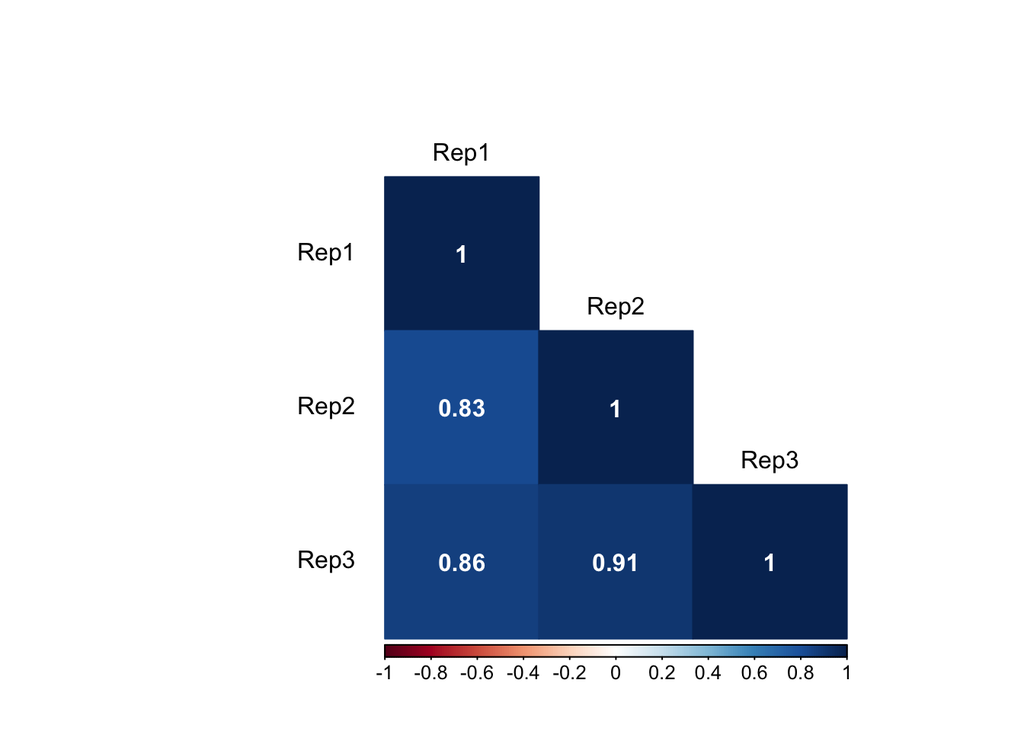

Figure 2.1: A correlation heatmap of the three reps. The number represents the correlation coefficient for each pair of reps.

### 2.1.1 Principle component analysis to identify sources of variance

Here, we use principle component analysis as a method if dimension reduction, to identify key drivers of variation in your data. We do this on the plant and fungal data separately, as otherwise the signal of the fungal data is lost due to the dominance of the plant reads.

#### 2.1.1.1 *B. distachyon* reads

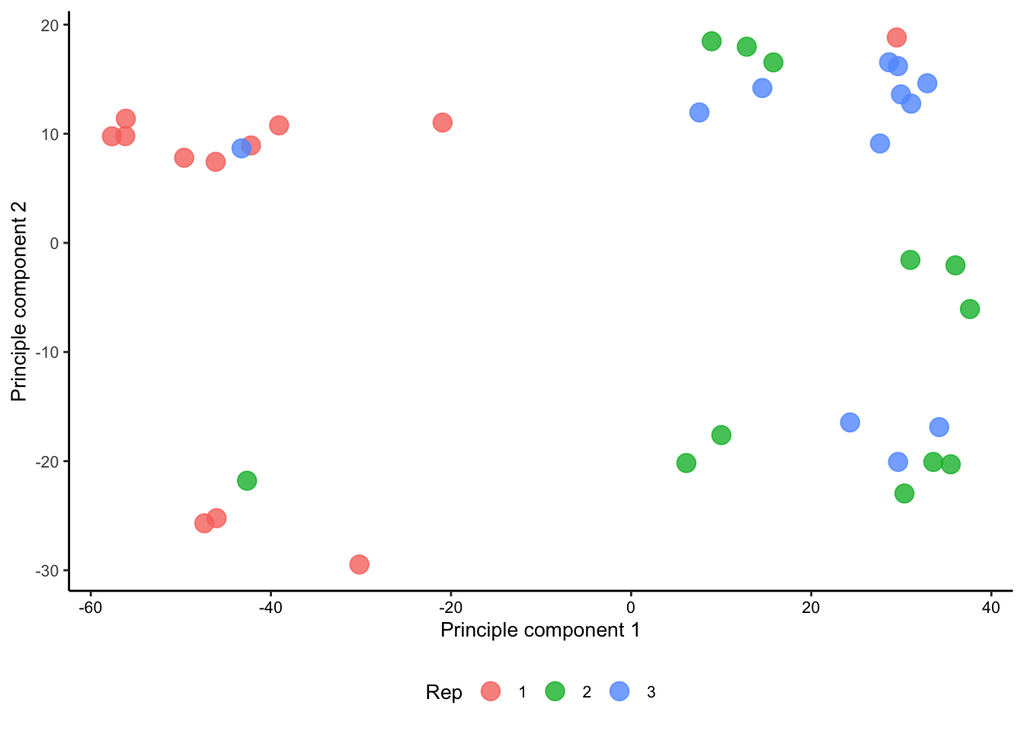

Figure 2.2: A principle component analysis of *B. distachyon* reads. Colours represent reps.

#### 2.1.1.2 *Z. tritici* reads

When we explore the *Z. tritici* reads only, we see a clear clustering based on timepoint, with T0 reads clustered together, separated from the other timepoints. This is to be expected (and is something I have seen before in my data - the early timepoint on its own). You can also see some level of clustering between the other timepoints, but these groups are not very clearly defined (Figure 2.3). The shapes of the points represent the isolates, and as you can see, there is not much variance that we can attribute to isolate.

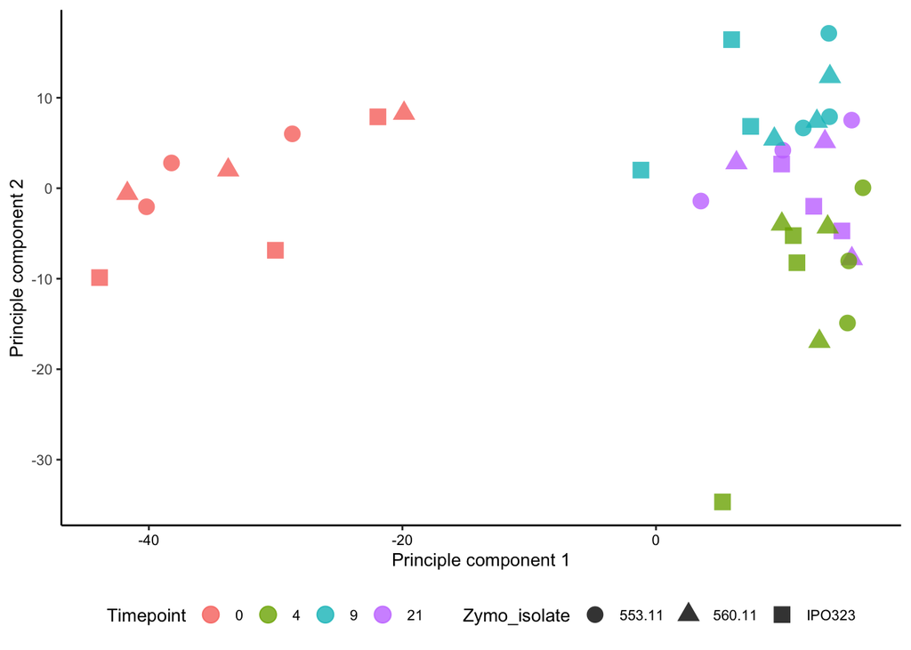

Figure 2.3: A principle component analysis of *Z. tritici* reads. Colours represent Timepoint and shape represents fungal isolate used.

### 2.1.2 Read count statistics

As part of the pre-processing of RNAseq data, it is good to asses and quantify the number of genes expressed in each sample. This is of particular importance when looking at dual RNAseq of a host + pathogen system. To do this, we filter out genes based on their expression level, and the consistency of their expression across the reps. Here, I have filtered genes that are expressed at 0.5 transcripts per million (TPM) or more, in 2 out of the three reps. For example, for ‘Gene A’ to be considered ‘expressed’ in Sample 1, timepoint 1, it would have to be expressed (TPM >=0.5) in 2 out of the three reps for that sample. Based on these criteria, we found a total of 55,420 genes to be expressed in this data, with an average of 46,781 genes expressed per sample (Table 2.1).  
Please note that these are fairly stringent filtering parameters, and may not be necessary, especially if you wish to detect pathogen genes that may be present at very low levels.

Table 2.1: Number of expressed genes per sample (averaged across reps)

| Sample | Number of expressed genes |
| --- | --- |
| 553.11 0 | 45736 |
| 553.11 21 | 47595 |
| 553.11 4 | 47779 |
| 553.11 9 | 47133 |
| 560.11 0 | 43716 |
| 560.11 21 | 48013 |
| 560.11 4 | 46770 |
| 560.11 9 | 47115 |
| IPO323 0 | 44305 |
| IPO323 21 | 47733 |
| IPO323 4 | 48077 |
| IPO323 9 | 47410 |

[figure not shown]

Figure 2.4: The number of expressed genes from both species across the 4 timepoints.

### 2.1.3 Differential expression analysis

In this sections, we explore differential gene expression between samples. As there are no *Z. tritici* controls (i.e. samples without *Z. tritici*), we can explore everything with respect to timepoint 0. We can also look at differences between isolates. Basically at this point I went rogue and did all comparisons; for each isolate, I compared every timepoint to 0 DPI, and for every timepoint, I compared every pair of isolates. This yielded to sets of differentially expressed genes.

Table 2.2: Number of differentally expressed genes

| Species | Timepoint | Comparison | Number of DEGs |
| --- | --- | --- | --- |
| Bd | 0 | 553.11 v IPO323 | 46 |
| Zt | 0 | 553.11 v IPO323 | 61 |
| Bd | 4 | 553.11 v IPO323 | 40 |
| Zt | 4 | 553.11 v IPO323 | 11 |
| Bd | 9 | 553.11 v IPO323 | 53 |
| Zt | 9 | 553.11 v IPO323 | 61 |
| Bd | 21 | 553.11 v IPO323 | 231 |
| Zt | 21 | 553.11 v IPO323 | 26 |
| Bd | 0 | 560.11 v 553.11 | 56 |
| Zt | 0 | 560.11 v 553.11 | 57 |
| Bd | 4 | 560.11 v 553.11 | 71 |
| Zt | 4 | 560.11 v 553.11 | 11 |
| Bd | 9 | 560.11 v 553.11 | 53 |
| Zt | 9 | 560.11 v 553.11 | 14 |
| Bd | 21 | 560.11 v 553.11 | 65 |
| Zt | 21 | 560.11 v 553.11 | 20 |
| Bd | 0 | 560.11 v IPO323 | 62 |
| Zt | 0 | 560.11 v IPO323 | 42 |
| Bd | 4 | 560.11 v IPO323 | 51 |
| Zt | 4 | 560.11 v IPO323 | 11 |
| Bd | 9 | 560.11 v IPO323 | 61 |
| Zt | 9 | 560.11 v IPO323 | 32 |
| Bd | 21 | 560.11 v IPO323 | 259 |
| Zt | 21 | 560.11 v IPO323 | 28 |

Table 2.3: Number of differentally expressed genes

| Species | Timepoint | Isolate | Number of DEGs |
| --- | --- | --- | --- |
| Bd | 4 | 553.11 | 828 |
| Zt | 4 | 553.11 | 1093 |
| Bd | 9 | 553.11 | 667 |
| Zt | 9 | 553.11 | 4151 |
| Bd | 21 | 553.11 | 270 |
| Zt | 21 | 553.11 | 1289 |
| Bd | 4 | 560.11 | 1309 |
| Zt | 4 | 560.11 | 584 |
| Bd | 9 | 560.11 | 365 |
| Zt | 9 | 560.11 | 504 |
| Bd | 21 | 560.11 | 301 |
| Zt | 21 | 560.11 | 465 |
| Bd | 4 | IPO323 | 282 |
| Zt | 4 | IPO323 | 412 |
| Bd | 9 | IPO323 | 164 |
| Zt | 9 | IPO323 | 113 |
| Bd | 21 | IPO323 | 710 |
| Zt | 21 | IPO323 | 371 |

#### 2.1.3.1 Isolate specific DEGs (per timepoint)

We can start to subset the differentially expressed genes based on interesting biological questions. Firsly, we can look at genes that are differentially expressed at a partcular timepoint (compared to 0 DPI) in 1, 2 or 3 of the isolates. Given the observed ‘aggresiveness’ of 553.11, it might be interesting to look at genes that are differentially expressed in this isolate, and not the others. Similarly, it might be interesting to see genes that are differentially expressed between the isolates, at each timepoint.  
First, we look at genes that are differentially expressed by timepoint.

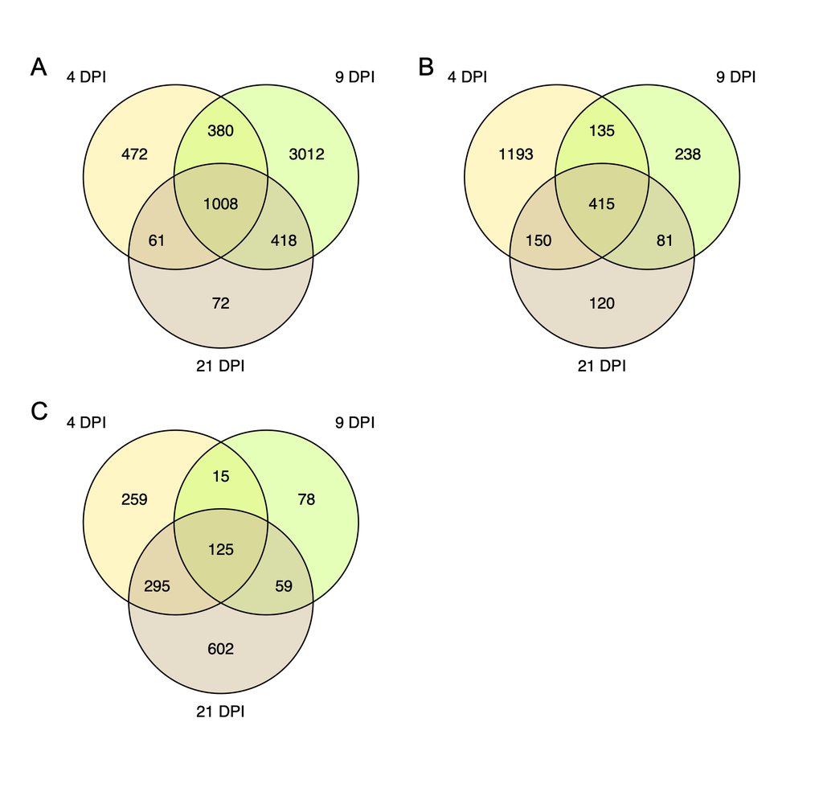